# **secr** simulations OU 2

Murray Efford

2025-07-10

# Spatial autocorrelation OU Version 2

The simulations described here are part of a series documenting the effect of breaching assumptions of spatially explicit capture–recapture models.

## Problem description

SECR assumes successive detections of an individual are independent events, conditional on the location of the activity centre. The Ornstein-Uhlenbeck distribution provides a serially correlated model of animal movement that may be used to test the effect of non-independence on SECR estimates.

## Settings

Square grid of 64 count proximity detectors at spacing 100 m.

The same conditions were used for simulation and fitting.

[output not shown]

Here ‘sigma’ is the overall scale of the O-U distribution and ‘tau’ determines the serial correlation. An animal is considered to be detected when it is within ‘epsilon’ of a detector at one of ‘noccasions’ sampling occasions.

## Package version, date and platform

```r
source('../setup.R')
runsim  <- FALSE
figures <- TRUE
cache   <- TRUE
nrepl   <- 200
metadata(runsim) # if FALSE picks up saved metadata.RDS
```

```
## R version 4.3.2 (2023-10-31)
## Platform   x86_64-pc-linux-gnu (64-bit)
## Running    Rocky Linux 9.4 (Blue Onyx)
## secr       5.2.5 2025-06-16
## secrdesign 2.10.1 2025-06-16
## Threads    40
## nrepl      200
## Run        Thu Jul 10 13:01:41 2025
```

## Changes

2025-07-10 recoded to use simOU functions in secr 5.2.5  
2025-07-10 ‘grdevice’ is set in setup.R to ‘ragg_png’ allowing graphics on NeSI

## Simulation code

From secr 5.2.5 it is possible to simulate OU movement and detection directly in secr. Detection happens when the location of an animal at one time step is within epsilon of a detector. The output capthist is a single-occasion sample.

```r
grid   <- make.grid(nx = 8, ny = 8, spacing = 100, detector = "count")
msk    <- make.mask(grid, buffer = 500, type = 'trapbuffer')
nstep  <- 100
fitarg <- list(detectfn = 'HHN', binomN = 1)
taulevels <- c(0.1, 1, 5, 10, 20, 50, 100)
scen <- make.scenarios( D = 2, epsilon = 10, sigma = 100, tau = taulevels,
                        noccasions = nstep, detectfn = 20)
```

```r
OUsims <- run.scenarios(
    nrepl       = nrepl,
    scenarios   = scen,
    trapset     = grid,
    maskset     = msk,
    fit         = TRUE,
    fit.args    = fitarg,
    seed        = 12345)
saveRDS(OUsims, file = 'OUsims.RDS')
```

OUsims completed with 200 replicates in 100 minutes.

## Results

First display some examples of movement tracks.

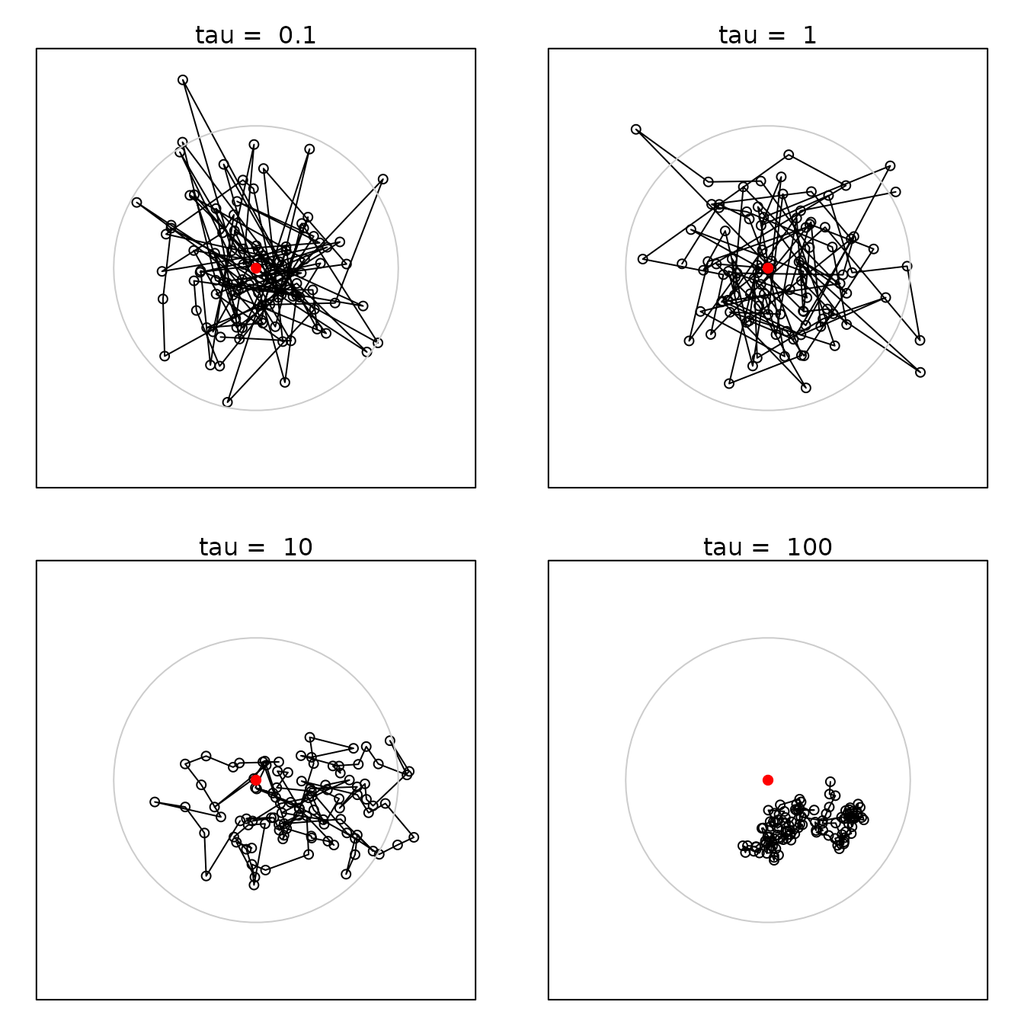

Figure: Examples of correlated movement paths over 100 time steps. Red dot is activity centre; grey circle is 95% contour of activity.

[figure not shown]

Figure: Bivariate normal sigma for varying tau and n.steps

```r
par(mfrow=c(2,2), mar = c(1,1,2,1), pty='s')
set.seed(123)
for (tau in c(0.1,1,10,100)) {
    locs <- simOU(matrix(c(0,0), nrow=1), tau = tau, sigma = 100, noccasions = 100)
    plot (locs, type='o', xlim=c(-350,350), ylim = c(-350,350), axes=F, xlab='', ylab='')
    mtext(side = 3, paste('tau = ', tau))
    points(0,0, pch = 16, col='red', cex = 1.2)
    box()
    symbols(0,0,circles=245,inches=FALSE, add = TRUE, fg = grey(0.8))
}
```

Check the mean sample sizes for each scenario

```
##     tau      n      r   nmov    dpa
## 1   0.1 166.53 232.00 187.24 2.1245
## 2   1.0 168.85 233.20 188.96 2.1185
## 3   5.0 163.59 233.84 181.12 2.1070
## 4  10.0 162.72 238.64 173.12 2.0641
## 5  20.0 155.19 244.14 154.73 1.9975
## 6  50.0 142.76 259.20 111.85 1.7839
## 7 100.0 127.28 273.79  67.53 1.5309
##  Variable Definition
##  tau      Autocorrelation parameter
##  n        Number of inndividuals
##  r        Number of recaptures
##  nmov     Number of movements
##  dpa      Detectors per individual
```

```
## Density
```

```
##     tau true.D nvalid    EST  seEST      RB   seRB    RSE   RMSE  rRMSE   COV
## 1   0.1      2    200 1.9940 0.0113 -0.0030 0.0056 0.0836 0.1591 0.0795 0.960
## 2   1.0      2    200 2.0269 0.0119  0.0134 0.0059 0.0831 0.1699 0.0849 0.965
## 3   5.0      2    200 1.9945 0.0117 -0.0027 0.0059 0.0837 0.1658 0.0829 0.950
## 4  10.0      2    200 2.0166 0.0121  0.0083 0.0061 0.0833 0.1719 0.0860 0.960
## 5  20.0      2    200 1.9692 0.0116 -0.0154 0.0058 0.0843 0.1669 0.0834 0.965
## 6  50.0      2    200 1.9160 0.0120 -0.0420 0.0060 0.0863 0.1891 0.0945 0.905
## 7 100.0      2    200 1.8019 0.0112 -0.0990 0.0056 0.0903 0.2534 0.1267 0.815
```

```
## lambda0
```

```
##     tau true.lambda0 nvalid    EST seEST
## 1   0.1           NA    200 0.0050 0e+00
## 2   1.0           NA    200 0.0050 0e+00
## 3   5.0           NA    200 0.0056 0e+00
## 4  10.0           NA    200 0.0063 0e+00
## 5  20.0           NA    200 0.0080 1e-04
## 6  50.0           NA    200 0.0143 1e-04
## 7 100.0           NA    197 0.0287 3e-04
```

```
## sigma
```

```
##     tau true.sigma nvalid     EST  seEST      RB   seRB    RSE    RMSE  rRMSE   COV
## 1   0.1        100    200  99.896 0.2859 -0.0010 0.0029 0.0391  4.0351 0.0404 0.940
## 2   1.0        100    200 100.080 0.3003  0.0008 0.0030 0.0390  4.2373 0.0424 0.940
## 3   5.0        100    200  94.326 0.2688 -0.0567 0.0027 0.0385  6.8242 0.0682 0.635
## 4  10.0        100    200  89.064 0.2961 -0.1094 0.0030 0.0376 11.7064 0.1171 0.190
## 5  20.0        100    200  79.674 0.2524 -0.2033 0.0025 0.0365 20.6358 0.2064 0.000
## 6  50.0        100    200  60.435 0.2358 -0.3956 0.0024 0.0341 39.7041 0.3970 0.000
## 7 100.0        100    198  44.208 0.1901 -0.5579 0.0019 0.0316 55.8558 0.5586 0.000
```

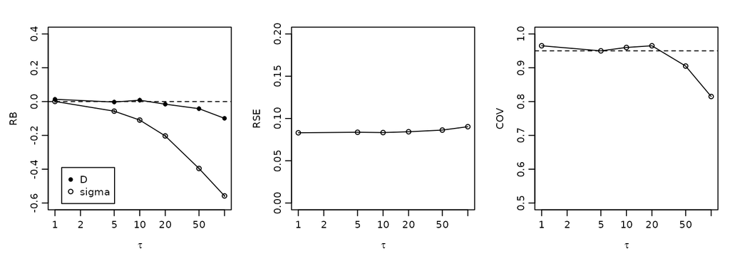

Figure: Relative bias RB, relative standard error RSE, and coverage of 95% confidence intervals COV for null-model density estimates from Ornstein-Uhlenbeck model with autocorrelation parameter tau.

## One-off

Run this code to obtain results for a single scenario.

```r
source('../setup.R')
grid   <- make.grid(nx = 8, ny = 8, spacing = 100, detector = "count")
msk    <- make.mask(grid, buffer = 500, type = 'trapbuffer')
fitarg <- list(binomN = 1, detectfn = 'HHN')
scen   <- make.scenarios( D = 2, epsilon = 10, sigma = 100, tau = 100,
                        noccasions = 100, detectfn = 20)
oneoff <- run.scenarios(nrepl = 10, scen, trapset = grid,  maskset = msk,
    fit = TRUE, fit.args = fitarg, seed = 12345)
```